# Modeling

Luming

2025-04-15

# Set up

```r
knitr::opts_chunk$set(echo = TRUE)

library(sf)
library(rsample)
library(tidymodels)
library(spatialsample)
library(mapview)
```

```r
load.fun <- function(x) {
  x <- as.character(x)
  if(isTRUE(x %in% .packages(all.available=TRUE))) {
    eval(parse(text=paste("require(", x, ")", sep="")))
    print(paste(c(x, " : already installed; requiring"), collapse=''))
  } else {
    #update.packages()
    print(paste(c(x, " : not installed; installing"), collapse=''))
    eval(parse(text=paste("install.packages('", x, "')", sep="")))
    print(paste(c(x, " : installed and requiring"), collapse=''))
    eval(parse(text=paste("require(", x, ")", sep="")))
  }
}

packages = c(
  # Core ML
  "tidymodels", "tidyverse",
  # Specific model packages
  "glmnet", "ranger", "xgboost",
  # Newer spatial packages
  "sf", "stars", "terra", "spatialsample", "nngeo", "mapview",
  # Newer extensions
  "finetune", "themis", "applicable", "vetiver",
  # Existing packages
  "bayesplot", "lme4", "RcppEigen", "AmesHousing"
)

for(i in seq_along(packages)){
  packge <- as.character(packages[i])
  load.fun(packge)
}

sessionInfo()
```

# Scenario Planning

## Predictive Modeling

### Models Training

Built on our simple OLS model, we train four models based on Ordinary Least Squares (OLS), Regularized Linear Regression, Random Forest, and XGBoost respectively for sales price predictions:

- **Ordinary Least Squares (OLS)** is a basic linear model that captures simple relationships but struggles with messy or complex data.
- **Regularized Linear Regression (RLS)** improves on OLS by adding penalties to reduce overfitting, making it useful for datasets with many or irrelevant variables.
- **Random Forest (RF)** averages many decision trees built on different data slices, handling complex patterns well but with less interpretability.
- **XGBoost (XGB)** builds trees sequentially, each learning from the last’s errors, excelling in accuracy for structured data tasks.

```r
set.seed(123)
theme_set(theme_bw())

"%!in%" <- Negate("%in%")
g <- glimpse

nn_function <- function(measureFrom,measureTo,k) {
  library(FNN)
  nn <-
    FNN::get.knnx(measureTo, measureFrom, k)$nn.dist
  output <-
    as.data.frame(nn) %>%
    rownames_to_column(var = "thisPoint") %>%
    gather(points, point_distance, V1:ncol(.)) %>%
    arrange(as.numeric(thisPoint)) %>%
    group_by(thisPoint) %>%
    summarize(pointDistance = mean(point_distance)) %>%
    arrange(as.numeric(thisPoint)) %>%
    dplyr::select(-thisPoint) %>%
    pull()

  return(output)
}
```

```r
property_CT_FE <- st_read("E:/Spring/Practicum/DataAnalysis/Chinatown/Dataset/property_CT_FE.geojson") %>%
  st_transform('EPSG:4326')

property_modeling <- property_CT_FE %>%
  mutate(
    Longitude = st_coordinates(.)[, 1],
    Latitude = st_coordinates(.)[, 2]
  ) %>%
  st_drop_geometry() %>%
  mutate(log_distance_to_city_hall = log(distance_to_city_hall +1),
         log_nearest_restaurant_dist_m = log (nearest_restaurant_dist_m +1),
         log_distance_to_nearest_park = log(distance_to_nearest_park +1),
         log_distance_to_nearest_water = log(distance_to_nearest_water+1),
         log_total_livable_area = log1p(total_livable_area),
         log_adj_sale_price = log(adj_sale_price+1)) %>%
  select(log_dist_highway,
         log_distance_to_city_hall,
         log_nearest_restaurant_dist_m,
         log_distance_to_nearest_park,
         zoning_group,
         zip_code,
         exterior_condition,
         interior_condition,
         log_total_livable_area,
         number_of_bathrooms,
         number_of_bedrooms,
         quality_grade,
         log_distance_to_nearest_water,
         central_air,
         year_built_group,
         # year_built,
         LPSS_PER1000,
         general_construction,
         garage_spaces,
         separate_utilities,
         category_code,
         crime_nn5,
         nhoods_name,
         landuse,
         log_adj_sale_price,
         Longitude, Latitude)

property_modeling_geo <- property_modeling %>%
  st_as_sf(coords = c("Longitude", "Latitude"), crs = 4326)

# write.csv(property_modeling, "E:/Spring/Practicum/DataAnalysis/Chinatown/Dataset/property_marketvalue/property_modeling.csv", row.names = FALSE)
# st_write(property_modeling_geo, "E:/Spring/Practicum/DataAnalysis/Chinatown/Dataset/property_marketvalue/property_modeling.geojson")

# Initial Split for Training and Test
set.seed(123)
data_split <- initial_split(property_modeling, strata = "log_adj_sale_price", prop = 0.7)
property_train <- training(data_split)
property_test  <- testing(data_split)


model_rec <- recipe(log_adj_sale_price ~ ., data = property_modeling) %>%
  # update_role(zoning_group, new_role = "zoning_group") %>%
  step_novel(all_nominal()) %>%
  step_other(all_nominal(), threshold = 0.01, other = "rare_level") %>%
  step_unknown(all_nominal()) %>%
  step_nzv(all_nominal()) %>%
  step_dummy(all_nominal()) %>%
  step_ns(Latitude, Longitude, options = list(df = 4),keep_original_cols=TRUE) %>%
  # step_corr(all_numeric_predictors(), threshold = 0.9) %>% # reduce multicollinearity
  step_zv(all_predictors()) %>%
  step_center(all_numeric_predictors()) %>%
  step_scale(all_numeric_predictors())
```

```r
# Moedl Specifications
lm_plan <-
  linear_reg() %>%
  set_engine("lm")

glmnet_plan <-
  linear_reg() %>%
  set_args(penalty  = tune()) %>%
  set_args(mixture  = tune()) %>%
  set_engine("glmnet")

rf_plan <- rand_forest() %>%
  set_args(mtry  = tune()) %>%
  set_args(min_n = tune()) %>%
  set_args(trees = 1000) %>%
  set_engine("ranger", importance = "impurity") %>%
  set_mode("regression")

XGB_plan <- boost_tree() %>%
  set_args(mtry  = tune()) %>%
  set_args(min_n = tune()) %>%
  set_args(trees = 100) %>%
  set_engine("xgboost") %>%
  set_mode("regression")

# Hyperparameter grid for glmnet (penalization)
glmnet_grid <- expand.grid(penalty = seq(0, 1, by = .25),
                           mixture = seq(0,1,0.25))
rf_grid <- expand.grid(mtry = c(2,5,10,13,30,45),
                       min_n = c(5,50,100,500))
xgb_grid <- expand.grid(mtry = c(3,5),
                        min_n = c(1,5))

# create workflow
lm_wf <-
  workflow() %>%
  add_recipe(model_rec) %>%
  add_model(lm_plan)
glmnet_wf <-
  workflow() %>%
  add_recipe(model_rec) %>%
  add_model(glmnet_plan)
rf_wf <-
  workflow() %>%
  add_recipe(model_rec) %>%
  add_model(rf_plan)
xgb_wf <-
  workflow() %>%
  add_recipe(model_rec) %>%
  add_model(XGB_plan)

# Spatial CV approach
property_train_sf <- st_as_sf(property_train, coords = c("Longitude", "Latitude"), crs = 4326)
property_train_sf <- property_train_sf %>%
  mutate(
    Longitude = st_coordinates(.)[, 1],
    Latitude = st_coordinates(.)[, 2]
  )
set.seed(123)
cv_splits_zoning <- group_vfold_cv(property_train,
                                group = "zoning_group")
set.seed(123)
cv_splits_cluster <- spatial_clustering_cv(
  property_train_sf,
  v = 20,
  cluster_function = "kmeans"
)

cv_splits_geo <- cv_splits_cluster
control <- control_resamples(save_pred = TRUE, verbose = TRUE)
metrics <- metric_set(rmse, rsq, mape, smape)
```

```r
# fit model to workflow and calculate metrics
lm_tuned <- lm_wf %>%
  tune::fit_resamples(.,
                      resamples = cv_splits_geo,
                      control   = control,
                      metrics   = metrics)

glmnet_tuned <- glmnet_wf %>%
  tune::tune_grid(.,
                  resamples = cv_splits_geo,
                  grid      = glmnet_grid,
                  control   = control,
                  metrics   = metrics)

rf_tuned <- rf_wf %>%
  tune::tune_grid(.,
                  resamples = cv_splits_geo,
                  grid      = rf_grid,
                  control   = control,
                  metrics   = metrics)

xgb_tuned <- xgb_wf %>%
  tune::tune_grid(.,
                  resamples = cv_splits_geo,
                  grid      = xgb_grid,
                  control   = control,
                  metrics   = metrics)

saveRDS(lm_tuned, "results/lm_tuned.rds")
saveRDS(glmnet_tuned, "results/glmnet_tuned.rds")
saveRDS(rf_tuned, "results/rf_tuned.rds")
saveRDS(xgb_tuned, "results/xgb_tuned.rds")
```

```r
lm_tuned     <- readRDS("results/lm_tuned.rds")
glmnet_tuned <- readRDS("results/glmnet_tuned.rds")
rf_tuned     <- readRDS("results/rf_tuned.rds")
xgb_tuned    <- readRDS("results/xgb_tuned.rds")
```

```r
# 'Best' by some metric and margin
lm_best_params     <- select_best(lm_tuned, metric = "rmse"    )
glmnet_best_params <- select_best(glmnet_tuned, metric = "rmse")
rf_best_params     <- select_best(rf_tuned, metric = "rmse"    )
xgb_best_params    <- select_best(xgb_tuned, metric = "rmse"   )

# Final workflow
lm_best_wf     <- finalize_workflow(lm_wf, lm_best_params)
glmnet_best_wf <- finalize_workflow(glmnet_wf, glmnet_best_params)
rf_best_wf     <- finalize_workflow(rf_wf, rf_best_params)
xgb_best_wf    <- finalize_workflow(xgb_wf, xgb_best_params)

# last_fit() emulates the process where, after determining the best model, the final fit on the entire training set is needed and is then evaluated on the test set.
lm_val_fit_geo <- lm_best_wf %>%
  last_fit(split     = data_split,
           control   = control,
           metrics   = metrics)

glmnet_val_fit_geo <- glmnet_best_wf %>%
  last_fit(split     = data_split,
           control   = control,
           metrics   = metrics)

rf_val_fit_geo <- rf_best_wf %>%
  last_fit(split     = data_split,
           control   = control,
           metrics   = metrics)

xgb_val_fit_geo <- xgb_best_wf %>%
  last_fit(split     = data_split,
           control   = control,
           metrics   = metrics)
```

```r
property_train_geo <- property_train %>%
  st_as_sf(coords = c("Longitude", "Latitude"), crs = 4326) %>%
  st_transform('EPSG:2272')
property_test_geo <- property_test %>%
  st_as_sf(coords = c("Longitude", "Latitude"), crs = 4326) %>%
  st_transform('EPSG:2272')


studyarea <- st_read("E:/Spring/Practicum/DataAnalysis/Chinatown/Dataset/studyarea/StudyArea.shp") %>%
  st_transform('EPSG:2272')
landuse <- st_read("E:/Spring/Practicum/DataAnalysis/Chinatown/Dataset/landuse_clip/Land_Use_ClipLayer.shp") %>%
  st_transform('EPSG:2272')
library(glue)
```

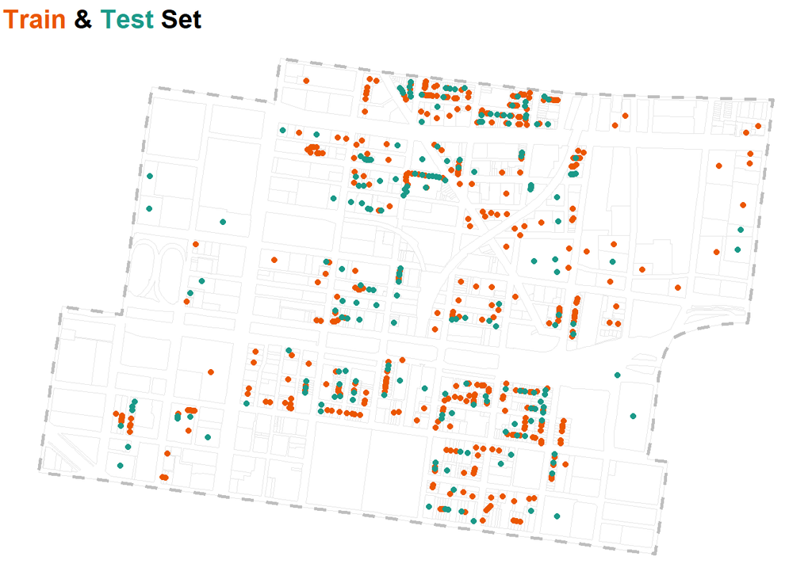

```r
ggplot() +
  geom_sf(data = landuse, fill = "white", color = "gray90", linewidth = 0.3) +
  geom_sf(data = studyarea, fill = "transparent", color = "grey", linetype = "dashed", linewidth = 1) +
  geom_sf(data = property_train_geo, color = "#eb5600") +
  geom_sf(data = property_test_geo, color = "#1a9988") +
  labs(title = glue("<span style='color:#eb5600;'>Train</span> & <span style='color:#1a9988;'>Test</span> Set")) +
  theme_void() +
  theme(plot.title = ggtext::element_markdown(size = 16, face = "bold"))
```

### Selecting the Best Model

The models are tested using Mean Absolute Error (MAE), Mean Absolute Percentage Error (MAPE) and prediction v.s. actual value scatter plot.

```r
# Pull best hyperparam preds from out-of-fold predictions
lm_best_OOF_preds <- collect_predictions(lm_tuned)

glmnet_best_OOF_preds <- collect_predictions(glmnet_tuned) %>%
  filter(penalty  == glmnet_best_params$penalty[1] & mixture == glmnet_best_params$mixture[1])

rf_best_OOF_preds <- collect_predictions(rf_tuned) %>%
  filter(mtry  == rf_best_params$mtry[1] & min_n == rf_best_params$min_n[1])

xgb_best_OOF_preds <- collect_predictions(xgb_tuned) %>%
  filter(mtry  == xgb_best_params$mtry[1] & min_n == xgb_best_params$min_n[1])

# collect validation set predictions from last_fit model
lm_val_pred_geo     <- collect_predictions(lm_val_fit_geo)
glmnet_val_pred_geo <- collect_predictions(glmnet_val_fit_geo)
rf_val_pred_geo     <- collect_predictions(rf_val_fit_geo)
xgb_val_pred_geo    <- collect_predictions(xgb_val_fit_geo)


# Aggregate OOF predictions (they do not overlap with Validation prediction set)
OOF_preds <- rbind(data.frame(dplyr::select(lm_best_OOF_preds, .pred, log_adj_sale_price), model = "OLS"),
                   data.frame(dplyr::select(glmnet_best_OOF_preds, .pred, log_adj_sale_price), model = "RLS"),
                   data.frame(dplyr::select(rf_best_OOF_preds, .pred, log_adj_sale_price), model = "RF"),
                   data.frame(dplyr::select(xgb_best_OOF_preds, .pred, log_adj_sale_price), model = "XGB")) %>%
  group_by(model) %>%
  mutate(actual_price = exp(log_adj_sale_price) - 1,
         predicted_price = exp(.pred) - 1,
         RMSE = yardstick::rmse_vec(actual_price, predicted_price),
         MAE  = yardstick::mae_vec(actual_price, predicted_price),
         MAPE = mean(abs(predicted_price - actual_price) / actual_price)) %>%
  ungroup() %>%
  mutate(model = factor(model, levels=c("OLS","RLS","RF","XGB")))

# Aggregate predictions from Validation set
# improve MAPE
val_preds <- rbind(data.frame(lm_val_pred_geo, model = "OLS"),
                   data.frame(glmnet_val_pred_geo, model = "RLS"),
                   data.frame(rf_val_pred_geo, model = "RF"),
                   data.frame(xgb_val_pred_geo, model = "XGB")) %>%
  left_join(., property_modeling %>%
              rowid_to_column(var = ".row") %>%
              dplyr::select(Latitude, Longitude, zoning_group, .row),
            by = ".row") %>%
  group_by(model) %>%
  mutate(
    actual_price = exp(log_adj_sale_price) - 1,
    predicted_price = exp(.pred) - 1
  ) %>%
  mutate(
    RMSE = yardstick::rmse_vec(actual_price, predicted_price),
    MAE  = yardstick::mae_vec(actual_price, predicted_price),
    MAPE = mean(abs(predicted_price - actual_price) / actual_price)
  ) %>%
  ungroup() %>%
  mutate(model = factor(model, levels=c("OLS","RLS","RF","XGB")))
```

```r
library(patchwork)
```

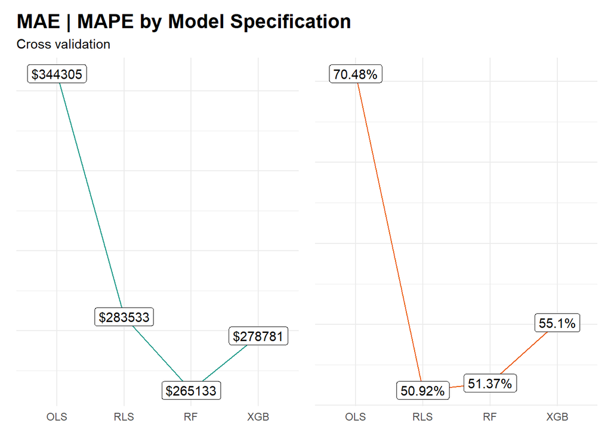

```r
library(glue)
# average error for each model
OOF_plot1 <- ggplot(data = OOF_preds %>%
         dplyr::select(model, MAE) %>%
         distinct() ,
       aes(x = model, y = MAE, group = 1)) +
  geom_path(color = "#1a9988") +
  geom_label(aes(label = paste0("$", round(MAE)))) +
  labs(title = "MAE | MAPE by Model Specification",
       subtitle = "Cross validation") +
  theme_minimal() +
  theme(plot.title = ggtext::element_markdown(size = 16, face = "bold"),
        axis.title = element_blank(),
        axis.text.y = element_blank())

OOF_plot2 <- ggplot(data = OOF_preds %>%
         dplyr::select(model, MAPE) %>%
         distinct() ,
       aes(x = model, y = MAPE, group = 1)) +
  geom_path(color = "#eb5600") +
  geom_label(aes(label = paste0(round(MAPE * 100,2),"%"))) +
  theme_minimal() +
  theme(
        axis.title = element_blank(),
        axis.text.y = element_blank())

# OOF predicted versus actual
OOF_plot3 <- ggplot(OOF_preds, aes(x = log_adj_sale_price, y = .pred, group = model)) +
  geom_point(alpha = 0.1, size = 0.5) +
  geom_abline(linetype = "dashed", color = "#1a9988") +
  geom_smooth(method = "lm", color = "#eb5600") +
  coord_equal() +
  facet_wrap(~model, nrow = 2) +
  labs(title = glue("<span style='color:#1a9988;'>Perfect</span> vs. <span style='color:#eb5600;'>Model</span> Prediction"),
       x = "Observed value", y = "Predicted value",
       subtitle = "Cross validation") +
  theme_minimal() +
  theme(plot.title = ggtext::element_markdown(size = 16, face = "bold"),
        axis.text = element_blank())

# plot MAPE by model type
val_plot1 <- ggplot(data = val_preds %>%
         dplyr::select(model, MAE) %>%
         distinct() ,
       aes(x = model, y = MAE, group = 1)) +
  geom_path(color = "#1a9988") +
  geom_label(aes(label = paste0("$", round(MAE)))) +
  labs(subtitle = "Test set validation") +
  theme_minimal() +
  theme(plot.title = ggtext::element_markdown(size = 16, face = "bold"),
        axis.title = element_blank(),
        axis.text.y = element_blank())

val_plot2 <- ggplot(data = val_preds %>%
         dplyr::select(model, MAPE) %>%
         distinct() ,
       aes(x = model, y = MAPE, group = 1)) +
  geom_path(color = "#eb5600") +
  geom_label(aes(label = paste0(round(MAPE * 100,2),"%"))) +
  theme_minimal() +
  theme(axis.title = element_blank(),
        axis.text.y = element_blank())

# Validation Predicted vs. actual
val_plot3 <- ggplot(val_preds, aes(x = log_adj_sale_price, y = .pred, group = model)) +
  geom_point(alpha = 0.1, size = 0.5) +
  geom_abline(linetype = "dashed", color = "#1a9988") +
  geom_smooth(method = "lm", color = "#eb5600") +
  coord_equal() +
  facet_wrap(~model, nrow = 2) +
  labs(x = "Observed value", y = "Predicted value",
       subtitle = "Test set validation") +
  theme_minimal() +
  theme(axis.text = element_blank())

OOF_plot1 | OOF_plot2
```

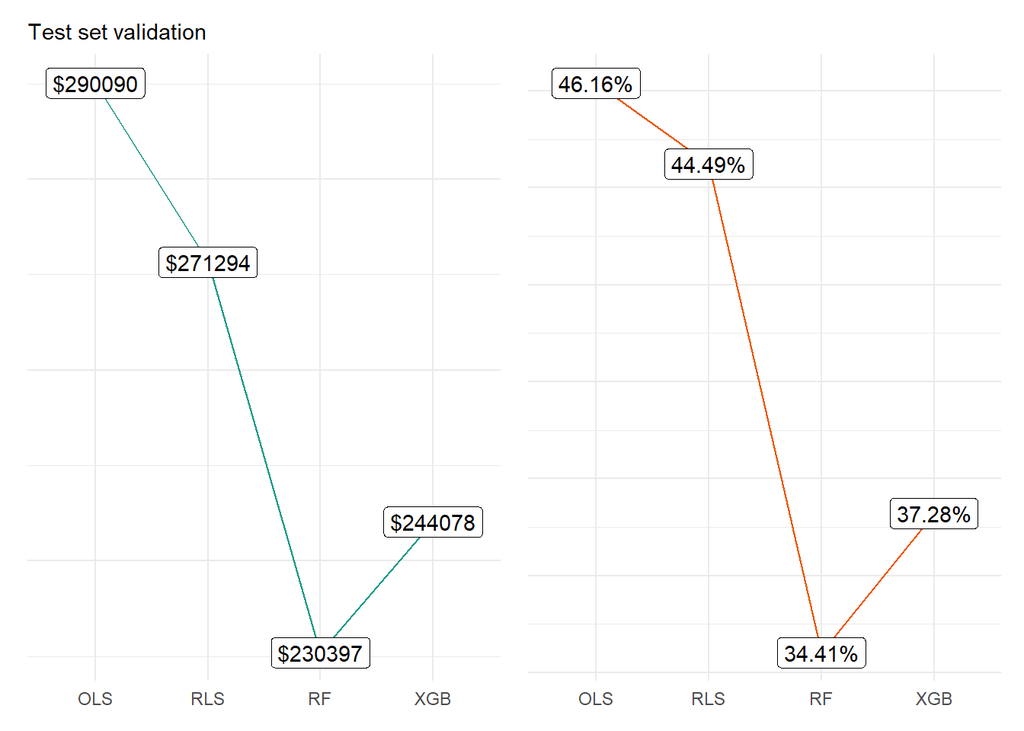

```r
val_plot1 | val_plot2
```

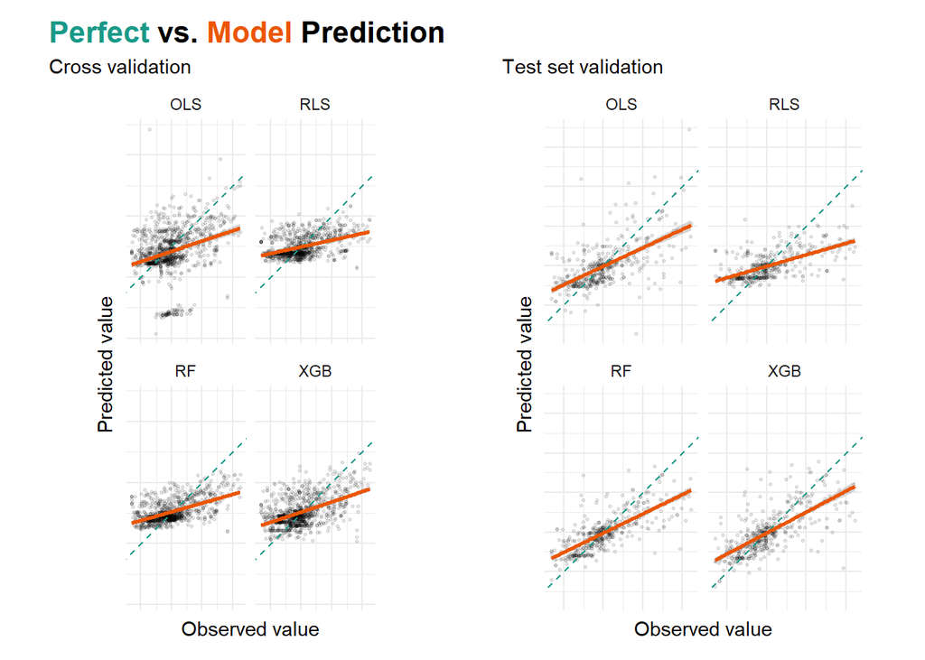

```r
OOF_plot3 | val_plot3
```

### Random Forest Model

```r
# join test data back to make spatial
val_pred_sf <- val_preds %>%
  group_by(model) %>%
  rowwise() %>%
  mutate(RMSE = yardstick::rmse_vec(actual_price, predicted_price),
    MAE  = yardstick::mae_vec(actual_price, predicted_price),
    MAPE = mean(abs(predicted_price - actual_price) / actual_price)) %>%
  st_as_sf(., coords = c("Longitude", "Latitude"),
           remove = FALSE,
           crs = 4326)

studyarea_4326 <- st_transform(studyarea, crs = 4326)

# map errors by point
mapview(filter(val_pred_sf, model == "RF"), zcol = "MAPE", cex = 5,
        layer.name = "RF MAPE")
```

[interactive chart not shown]

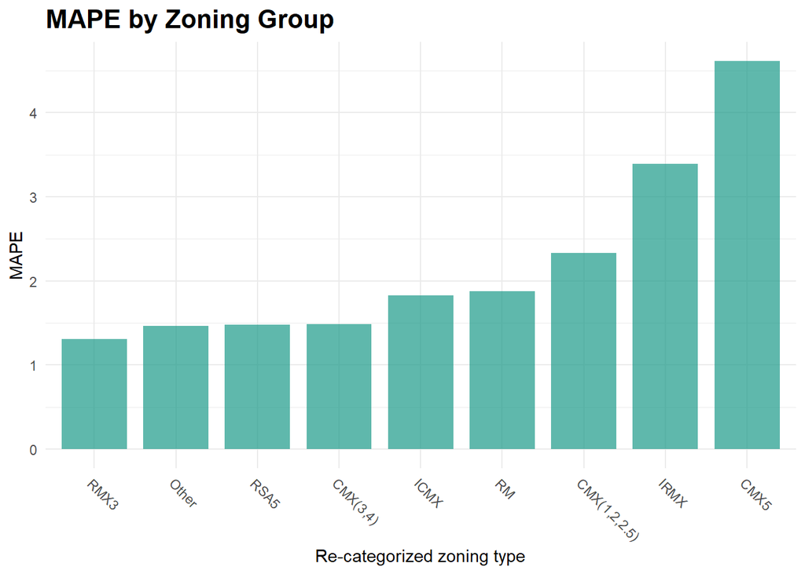

```r
# aggregate val error to Neighborhood
val_MAPE_by_zoning <- val_preds %>%
  group_by(zoning_group, model) %>%
  summarise(RMSE = yardstick::rmse_vec(actual_price, predicted_price),
    MAE  = yardstick::mae_vec(actual_price, predicted_price),
    MAPE = mean(abs(predicted_price - actual_price) / actual_price)) %>%
  ungroup()

# plot MAPE by Hood
ggplot(val_MAPE_by_zoning, aes(x = reorder(zoning_group, MAPE), y = MAPE)) +
  geom_bar(stat = "identity", fill = "#1a9988", width = .8, alpha = .7) +
  # scale_y_continuous(breaks = seq(0,10,1)) +
  labs(x = "Re-categorized zoning type",
       title = "MAPE by Zoning Group") +
  theme_minimal() +
  theme(plot.title = element_text(size = 16, face = "bold"),
    axis.text.x = element_text(angle = -45, hjust = 0)
  )
```

```r
table(property_modeling$zoning_group)
```

```
##
## CMX(1,2,2.5)     CMX(3,4)         CMX5         ICMX         IRMX        Other
##           40         1065           21           11           38           42
##           RM         RMX3         RSA5
##          152          113           46
```

we don’t focus on IRMX and CMX5 so our model behaves well for the situation here.

```r
## Fit and Extract final model
## Final fit on all data
full_fit_lm     <- lm_best_wf %>% fit(property_modeling)
full_fit_glmnet <- glmnet_best_wf %>% fit(property_modeling)
full_fit_rf     <- rf_best_wf %>% fit(property_modeling)
full_fit_xgb    <- xgb_best_wf %>% fit(property_modeling)

# extract final fit model object as native package type
lm_full_mod     <- full_fit_lm  $fit$fit$fit
glmnet_full_mod <- full_fit_glmnet$fit$fit$fit
rf_full_mod     <- full_fit_rf  $fit$fit$fit
xgb_full_mod    <- full_fit_xgb $fit$fit$fit

saveRDS(lm_full_mod,     file = "results/lm_model.rds")
saveRDS(glmnet_full_mod, file = "results/glmnet_model.rds")
saveRDS(rf_full_mod,     file = "results/rf_model.rds")
saveRDS(xgb_full_mod,    file = "results/xgb_model.rds")
```

## Scenario Predictions

```r
rf_model_loaded     <- readRDS("results/rf_model.rds")
```

### Scenario 1: Stitch Built

```r
# rf_pred <- predict(rf_full_mod, data = scenario_2)
# exp(rf_pred$predictions)
```